# Final Project Phase 3

# EDA

## Data Cleaning Tools

```python
!pip install nltk
```

```python
import nltk
nltk.download('stopwords')
nltk.download('punkt')
```

```
True
```

```python
from nltk.corpus import stopwords
from nltk.tokenize import word_tokenize
import re
stop_words = set(stopwords.words('english'))


def remove_url(txt):
    """Replace URLs found in a text string with nothing
    (i.e. it will remove the URL from the string).
    """
    return re.sub("([^0-9A-Za-z \t])|(\w+:\/\/\S+)", "", txt)

def remove_stop_words(txt):
    """lower case the text, and DROP stop words. """
    return " ".join([w for w in word_tokenize(txt.lower()) if not w in stop_words])

def preprocess_tweet_text(txt):
    return remove_stop_words(remove_url(txt))
```

```python
# Remove URLs and Stop Words
df['filtered_text'] = df.Tweet_Text.apply(preprocess_tweet_text)

#retweet
df['retweet_flags'] = df.Tweet_Text.str.startswith('RT')

# TODO Add code analyse URLs, their domains, categories etc.

df.head()
```

|  | Hashtags | ID | Tweet_Text | Name | Username | User_Location | User_Description | Followers | Friends | Lists | Account_Creation_Date | Favorites | User_Total_Tweets | Num_Tweets_Rank | Tweet_Rank | filtered_text | retweet_flags |
| --- | --- | --- | --- | --- | --- | --- | --- | --- | --- | --- | --- | --- | --- | --- | --- | --- | --- |
| 99817 | [] | 1.254560e+18 | Turns out I’ve been a fool for not listening t... | ✨🔮Crystal 🔮✨ | _Crystalosaurus | The Afterlife in Beetlejuice | Writer. Drinker of iced coffee. Petter of dogs... | 184 | 661 | 5 | Sat Jun 27 23:03:55 +0000 2009 | 18352 | 21005 | 27239.0 | 0.6805 | turns ive fool listening dua lipas music | False |
| 99816 | [] | 1.254560e+18 | RT @calebturner_10: The amount of snap stories... | s o f | itssofiaosmani | Cali | 🇦🇫 | 465 | 297 | 2 | Sun May 31 20:11:36 +0000 2009 | 69134 | 31436 | 22030.0 | 3.1593 | rt calebturner10 amount snap stories ive seen ... | True |
| 99815 | [] | 1.254560e+18 | RT @_DashawnJ_: JADED by Drake is a timeless s... | Lex ✨🌙 | justlexi95 | NaN | Dog mom to Kash ❤️ | 337 | 255 | 0 | Fri Nov 09 01:36:33 +0000 2012 | 25462 | 8296 | 36262.0 | 0.7115 | rt dashawnj jaded drake timeless song | True |
| 99814 | ['TousEnsemble', 'StrongerTogether'] | 1.254560e+18 | ...Drake is still talking #TousEnsemble #Stron... | Erin Pepler | erinpepler | Toronto, Ontario | Writer, mom, consumer of overpriced coffee. By... | 1409 | 1883 | 54 | Tue May 13 17:54:33 +0000 2008 | 11911 | 6190 | 38127.0 | 0.3494 | drake still talking tousensemble strongertogether | False |
| 99813 | [] | 1.254560e+18 | I still can’t believe Juice Wrld is gone. \n\n... | Hannah 🧸 | hannah_banna24 | 🤷🏼‍♀️ Who tf knows | \|Instagram: hannahmlorenzen\| ~No matter where ... | 249 | 524 | 0 | Sun Jun 24 20:55:32 +0000 2018 | 10080 | 6358 | 37966.0 | 0.2721 | still cant believe juice wrld gone cant believ... | False |

## Analyzing Data

Here, we will create DataFrames for each artist:

- DataFrames will be formed by a regular expression that searches for the artist name and song name (song that put the artist in the top charts).
- There will be two DataFrames per artist - one that searches 'Tweet_Text' (content of the tweet) and one that searches 'Hashtags'.
- Artists in both the Apple and Spotify top 10 will both be considered and all artists will be ranked
- These DataFrames will help us create our own top 10 ranking later on

```python
import re
# dataframe for Travis Scott tweets and hashtags
travis_tweets = df[df['Tweet_Text'].str.contains("travis scott|the scotts", flags=re.IGNORECASE)]
travis_hashtags = df[df['Hashtags'].str.contains("travisscott|thescotts", flags=re.IGNORECASE)]

# dataframe for The Weeknd tweets and hashtags
weeknd_tweets = df[df['Tweet_Text'].str.contains("weeknd|blinding lights", flags=re.IGNORECASE)]
weeknd_hashtags = df[df['Hashtags'].str.contains("weeknd|blindinglights", flags=re.IGNORECASE)]

# dataframe for Drake tweets and hashtags
drake_tweets = df[df['Tweet_Text'].str.contains("drake|toosie slide", flags=re.IGNORECASE)]
drake_hashtags = df[df['Hashtags'].str.contains("drake|toosieslide", flags=re.IGNORECASE)]

# dataframe for SAINt JHN tweets and hashtags
"""
Note that "roses" could return many results not related to the song. This is the case for a few of the
songs on this list, but this one especially could yield some results we don't want. We'll put the full title
with the expectation that this may not give us a ton of extra results as most Twitter users likely wouldn't
type this whole thing out. For hashtags, we'll just use #saintjhn
"""
saintjhn_tweets = df[df['Tweet_Text'].str.contains("saint jhn|roses - imanbek remix|roses imanbek", flags=re.IGNORECASE)]
saintjhn_hashtags = df[df['Hashtags'].str.contains("saintjhn", flags=re.IGNORECASE)]

# dataframe for Dua Lipa tweets and hashtags
dua_tweets = df[df['Tweet_Text'].str.contains("dua lipa|dont start now|don't start now", flags=re.IGNORECASE)]
dua_hashtags = df[df['Hashtags'].str.contains("dualipa|dontstartnow", flags=re.IGNORECASE)]

# dataframe for Powfu tweets and hashtags
powfu_tweets = df[df['Tweet_Text'].str.contains("powfu|death bed|coffee for your head", flags=re.IGNORECASE)]
powfu_hashtags = df[df['Hashtags'].str.contains("powfu|deathbed", flags=re.IGNORECASE)]

# dataframe for Juice WRLD tweets and hashtags
juice_tweets = df[df['Tweet_Text'].str.contains("juice wlrd|righteous", flags=re.IGNORECASE)]
juice_hashtags = df[df['Hashtags'].str.contains("juicewrld|righteous", flags=re.IGNORECASE)]

# dataframe for Tones and I tweets and hashtags
tones_tweets = df[df['Tweet_Text'].str.contains("tones and i|dance monkey", flags=re.IGNORECASE)]
tones_hashtags = df[df['Hashtags'].str.contains("tonesandi|dancemonkey", flags=re.IGNORECASE)]

# dataframe for Roddy Rich tweets and hashtags
roddy_tweets = df[df['Tweet_Text'].str.contains("roddy rich|the box", flags=re.IGNORECASE)]
roddy_hashtags = df[df['Hashtags'].str.contains("roddyrich|thebox", flags=re.IGNORECASE)]

# dataframe for Lil Mosey tweets and hashtags
mosey_tweets = df[df['Tweet_Text'].str.contains("lil mosey|blueberry faygo", flags=re.IGNORECASE)]
# mosey_hashtags = df[df['Hashtags'].str.contains("lilmosey|blueberryfaygo", flags=re.IGNORECASE)]
# Lil Mosey didn't have any hashtag mentions, so we will only factor in tweets for him

# dataframe for Lil Baby tweets and hashtags
lilbaby_tweets = df[df['Tweet_Text'].str.contains("lil baby|rockstar", flags=re.IGNORECASE)]
lilbaby_hashtags = df[df['Hashtags'].str.contains("lilbaby|rockstar", flags=re.IGNORECASE)]

# dataframe for Youngboy Never Broke Again tweets and hashtags
youngboy_tweets = df[df['Tweet_Text'].str.contains("youngboy|diamonds", flags=re.IGNORECASE)]
youngboy_hashtags = df[df['Hashtags'].str.contains("youngboy|youngboyneverbrokeagain|diamonds", flags=re.IGNORECASE)]

# dataframe for DaBaby tweets and hashtags
dababy_tweets = df[df['Tweet_Text'].str.contains("dababy|da baby|jump", flags=re.IGNORECASE)]
dababy_hashtags = df[df['Hashtags'].str.contains("dababy|jump", flags=re.IGNORECASE)]
```

## Applying our Tweet Rating Metric

- For each artist, we will find the average Tweet rating for the tweet text DataFrame and the hashtag DataFrame

```python
travis_tweets_rank = np.mean(travis_tweets['Tweet_Rank'])
travis_hashtags_rank = np.mean(travis_hashtags['Tweet_Rank'])
travis_avg_rank = (travis_tweets_rank + travis_hashtags_rank) / 2

print(f"Travis Scott's average tweet rank is: {np.round(travis_tweets_rank,2)}")
print(f"Travis Scott's average hashtag rank is: {np.round(travis_hashtags_rank,2)}")
print("-"*50)

weeknd_tweets_rank = np.mean(weeknd_tweets['Tweet_Rank'])
weeknd_hashtags_rank = np.mean(weeknd_hashtags['Tweet_Rank'])
weeknd_avg_rank = (weeknd_tweets_rank + weeknd_hashtags_rank) / 2

print(f"The Weeknd's average tweet rank is: {np.round(weeknd_tweets_rank,2)}")
print(f"The Weeknd's average hashtag rank is: {np.round(weeknd_hashtags_rank,2)}")
print("-"*50)

drake_tweets_rank = np.mean(drake_tweets['Tweet_Rank'])
drake_hashtags_rank = np.mean(drake_hashtags['Tweet_Rank'])
drake_avg_rank = (drake_tweets_rank + drake_hashtags_rank) / 2

print(f"Drake's average tweet rank is: {np.round(drake_tweets_rank,2)}")
print(f"Drake's average hashtag rank is: {np.round(drake_hashtags_rank,2)}")
print("-"*50)

saintjhn_tweets_rank = np.mean(saintjhn_tweets['Tweet_Rank'])
saintjhn_hashtags_rank = np.mean(saintjhn_hashtags['Tweet_Rank'])
saintjhn_avg_rank = (saintjhn_tweets_rank + saintjhn_hashtags_rank) / 2

print(f"SaINt JHN's average tweet rank is: {np.round(saintjhn_tweets_rank,2)}")
print(f"SaINt JHN's average hashtag rank is: {np.round(saintjhn_hashtags_rank,2)}")
print("-"*50)

dua_tweets_rank = np.mean(dua_tweets['Tweet_Rank'])
dua_hashtags_rank = np.mean(dua_hashtags['Tweet_Rank'])
dua_avg_rank = (dua_tweets_rank + dua_hashtags_rank) / 2

print(f"Dua Lipa's average tweet rank is: {np.round(dua_tweets_rank,2)}")
print(f"Dua Lipa's average hashtag rank is: {np.round(dua_hashtags_rank,2)}")
print("-"*50)

powfu_tweets_rank = np.mean(powfu_tweets['Tweet_Rank'])
powfu_hashtags_rank = np.mean(powfu_hashtags['Tweet_Rank'])
powfu_avg_rank = (powfu_tweets_rank + powfu_hashtags_rank) / 2

print(f"Powfu's average tweet rank is: {np.round(powfu_tweets_rank,2)}")
print(f"Powfu's average hashtag rank is: {np.round(powfu_hashtags_rank,2)}")
print("-"*50)

juice_tweets_rank = np.mean(juice_tweets['Tweet_Rank'])
juice_hashtags_rank = np.mean(juice_hashtags['Tweet_Rank'])
juice_avg_rank = (juice_tweets_rank + juice_hashtags_rank) / 2

print(f"Juice WRLD's average tweet rank is: {np.round(juice_tweets_rank,2)}")
print(f"Juice WLRD's average hashtag rank is: {np.round(juice_hashtags_rank,2)}")
print("-"*50)

tones_tweets_rank = np.mean(tones_tweets['Tweet_Rank'])
tones_hashtags_rank = np.mean(tones_hashtags['Tweet_Rank'])
tones_avg_rank = (tones_tweets_rank + tones_hashtags_rank) / 2

print(f"Tones and I's average tweet rank is: {np.round(tones_tweets_rank,2)}")
print(f"Tones and I's average hashtag rank is: {np.round(tones_hashtags_rank,2)}")
print("-"*50)

roddy_tweets_rank = np.mean(roddy_tweets['Tweet_Rank'])
roddy_hashtags_rank = np.mean(roddy_hashtags['Tweet_Rank'])
roddy_avg_rank = (roddy_tweets_rank + roddy_hashtags_rank) / 2

print(f"Roddy Rich's average tweet rank is: {np.round(roddy_tweets_rank,2)}")
print(f"Roddy Rich's average hashtag rank is: {np.round(roddy_hashtags_rank,2)}")
print("-"*50)

mosey_tweets_rank = np.mean(mosey_tweets['Tweet_Rank'])
print(f"Lil Mosey's average tweet rank is: {np.round(mosey_tweets_rank,2)}")

print("-"*50)

lilbaby_tweets_rank = np.mean(lilbaby_tweets['Tweet_Rank'])
lilbaby_hashtags_rank = np.mean(lilbaby_hashtags['Tweet_Rank'])
lilbaby_avg_rank = (lilbaby_tweets_rank + lilbaby_hashtags_rank) / 2

print(f"Lil Baby's average tweet rank is: {np.round(lilbaby_tweets_rank,2)}")
print(f"Lil Baby's average hashtag rank is: {np.round(lilbaby_hashtags_rank,2)}")
print("-"*50)

youngboy_tweets_rank = np.mean(youngboy_tweets['Tweet_Rank'])
youngboy_hashtags_rank = np.mean(youngboy_hashtags['Tweet_Rank'])
youngboy_avg_rank = (youngboy_tweets_rank + youngboy_hashtags_rank) / 2

print(f"Youngboy's average tweet rank is: {np.round(youngboy_tweets_rank,2)}")
print(f"Youngboy's average hashtag rank is: {np.round(youngboy_hashtags_rank,2)}")
print("-"*50)

dababy_tweets_rank = np.mean(dababy_tweets['Tweet_Rank'])
dababy_hashtags_rank = np.mean(dababy_tweets['Tweet_Rank'])
dababy_avg_rank = (dababy_tweets_rank + dababy_hashtags_rank) / 2

print(f"DaBaby's average tweet rank is: {np.round(dababy_tweets_rank,2)}")
print(f"DaBaby's average hashtag rank is: {np.round(dababy_hashtags_rank,2)}")
print("-"*50)
```

```
Travis Scott's average tweet rank is: 6.48
Travis Scott's average hashtag rank is: 1.48
--------------------------------------------------
The Weeknd's average tweet rank is: 6.33
The Weeknd's average hashtag rank is: 13.28
--------------------------------------------------
Drake's average tweet rank is: 8.76
Drake's average hashtag rank is: 4.78
--------------------------------------------------
SaINt JHN's average tweet rank is: 3.57
SaINt JHN's average hashtag rank is: 15.92
--------------------------------------------------
Dua Lipa's average tweet rank is: 18.63
Dua Lipa's average hashtag rank is: 5.32
--------------------------------------------------
Powfu's average tweet rank is: 26.0
Powfu's average hashtag rank is: 27.04
--------------------------------------------------
Juice WRLD's average tweet rank is: 92.45
Juice WLRD's average hashtag rank is: 1.99
--------------------------------------------------
Tones and I's average tweet rank is: 29.83
Tones and I's average hashtag rank is: 6.92
--------------------------------------------------
Roddy Rich's average tweet rank is: 7.83
Roddy Rich's average hashtag rank is: 1.56
--------------------------------------------------
Lil Mosey's average tweet rank is: 0.69
--------------------------------------------------
Lil Baby's average tweet rank is: 4.93
Lil Baby's average hashtag rank is: 0.99
--------------------------------------------------
Youngboy's average tweet rank is: 2.08
Youngboy's average hashtag rank is: 0.37
--------------------------------------------------
DaBaby's average tweet rank is: 28.82
DaBaby's average hashtag rank is: 28.82
--------------------------------------------------
```

## Getting an Artist's Final Ranking

- To determine where an artist should fall on our ranking, we will multiply the following:
  - Number of tweets about the artist or song plus number of hashtags about the artist or song
  - 1/2 of the average of tweet and hashtag ratings

```python
# totals - hashtag dataframes plus tweet dataframes
travis_total = len(travis_tweets)+len(travis_hashtags)
weeknd_total = len(weeknd_tweets)+len(weeknd_hashtags)
drake_total = len(drake_tweets)+len(drake_hashtags)
saintjhn_total = len(saintjhn_tweets)+len(saintjhn_hashtags)
dua_total = len(dua_tweets)+len(dua_hashtags)
powfu_total = len(powfu_tweets)+len(powfu_hashtags)
juice_total = len(juice_tweets)+len(juice_hashtags)
tones_total = len(tones_tweets)+len(tones_hashtags)
roddy_total = len(roddy_tweets)+len(roddy_hashtags)
mosey_total = len(mosey_tweets) # hashtags not included because he didn't have any
lilbaby_total = len(lilbaby_tweets)+len(lilbaby_hashtags)
youngboy_total = len(youngboy_tweets)+len(youngboy_hashtags)
dababy_total = len(dababy_tweets)+len(dababy_hashtags)
```

```python
# final rankings - totals multiplied by 1/2 of the average tweet and hashtag ranks
travis_final = travis_total*(.5*travis_avg_rank)
print(f"Travis Scott's final rating is {np.round(travis_final,2)}")

weeknd_final = weeknd_total*(.5*weeknd_avg_rank)
print(f"The Weeknd's final rating is {np.round(weeknd_final,2)}")

drake_final = drake_total*(.5*drake_avg_rank)
print(f"Drake's final rating is {np.round(drake_final,2)}")

saintjhn_final = saintjhn_total*(.5*saintjhn_avg_rank)
print(f"SaINt JHN's final rating is {np.round(saintjhn_final,2)}")

dua_final = dua_total*(.5*dua_avg_rank)
print(f"Dua Lipa's final rating is {np.round(dua_final,2)}")

powfu_final = powfu_total*(.5*powfu_avg_rank)
print(f"Powfu's final rating is {np.round(powfu_final,2)}")

juice_final = juice_total*(.5*juice_avg_rank)
print(f"Juice WRLD's final rating is {np.round(juice_final,2)}")

tones_final = tones_total*(.5*tones_avg_rank)
print(f"Tones and I's final rating is {np.round(tones_final,2)}")

roddy_final = roddy_total*(.5*roddy_avg_rank)
print(f"Roddy Rich's final rating is {np.round(roddy_final,2)}")

mosey_final = mosey_total*(.5*mosey_tweets_rank)
print(f"Lil Mosey's final rating is {np.round(mosey_final,2)}")

lilbaby_final = lilbaby_total*(.5*lilbaby_avg_rank)
print(f"Lil Baby's final rating is {np.round(lilbaby_final,2)}")

youngboy_final = youngboy_total*(.5*youngboy_avg_rank)
print(f"Youngboy's final rating is {np.round(youngboy_final,2)}")

dababy_final = dababy_total*(.5*dababy_avg_rank)
print(f"DaBaby's final rating is {np.round(dababy_final,2)}")
```

```
Travis Scott's final rating is 18057.49
The Weeknd's final rating is 1505.36
Drake's final rating is 50832.67
SaINt JHN's final rating is 711.22
Dua Lipa's final rating is 10561.02
Powfu's final rating is 344.81
Juice WRLD's final rating is 5831.17
Tones and I's final rating is 174.57
Roddy Rich's final rating is 668.92
Lil Mosey's final rating is 9.37
Lil Baby's final rating is 3346.18
Youngboy's final rating is 1453.8
DaBaby's final rating is 41916.41
```

# Apple Versus Spotify: a contrastive study

## One Big Artist DataFrame

contains:

- **Artist**
- **Total_Tweets**
  - total tweets about the artist or song
- **Total_Hashtags**
  - total tweets that have hashtags about the artist or song
- **Total_Tweet_Rating**
  - avg rating of total tweets about the artist or song
- **Total_Hashtags_Rating**
  - avg rating of total hashtags about the artist or song
- **Final_Rating**
  - factors in aforementioned equation to get a final rating

```python
final_ranking = {'Artist':  ['Travis Scott','The Weeknd','Drake','SaINt JHN','Dua Lipa','Powfu','Juice WRLD',
                'Tones And I','Roddy Rich','Lil Mosey','Lil Baby','YoungBoy Never Broke Again', 'DaBaby'],
        'Final_Rating': [travis_final,weeknd_final,drake_final,saintjhn_final,dua_final,powfu_final,juice_final,
                        tones_final,roddy_final,mosey_final,lilbaby_final,youngboy_final,dababy_final]
        }

final_ranking = pd.DataFrame (final_ranking, columns = ['Artist','Final_Rating'])

##################################################################################################
# dataframe for us vs apple and us vs spotify
us_vs_apple = pd.merge(final_ranking,apple_top_10,on='Artist',how='inner')
us_vs_apple['Our_Position'] = us_vs_apple['Final_Rating'].rank(ascending=False)

us_vs_spotify = pd.merge(final_ranking,spotify_top_10,on='Artist',how='inner')
us_vs_spotify['Our_Position'] = us_vs_spotify['Final_Rating'].rank(ascending=False)

final_ranking['Our_Rank'] = final_ranking['Final_Rating'].rank(ascending=False)

###################################################################################################

#final_ranking = pd.merge(final_ranking, all_rankings, left_index=True, right_index=True)
#all_rankings = all_rankings.rename(columns={'Track': 'Track: Spotify', 'Artist': 'Artist: Spotify', 'Position': 'Position: Spotify'})
combined_df = pd.merge(spotify_top_10, apple_top_10, on='Artist', how='outer')
combined_df
final_ranking = pd.merge(final_ranking,combined_df,on='Artist',how='outer')
final_ranking = final_ranking.drop(columns={"Track_x", "Track_y"})
final_ranking = final_ranking.rename(columns={"Position_x": "Spotify_Position",
                                              "Position_y": "Apple_Position",
                                             "Our_Rank": "Our_Position"})

final_ranking = final_ranking.replace(to_replace="YoungBoy Never Broke Again",value="YoungBoy") # just making his name shorter
us_vs_apple = us_vs_apple.replace(to_replace="YoungBoy Never Broke Again",value="YoungBoy") # just making his name shorter
us_vs_spotify = us_vs_spotify.replace(to_replace="YoungBoy Never Broke Again",value="YoungBoy") # just making his name shorter



final_ranking.sort_values('Our_Position')
```

|  | Artist | Final_Rating | Our_Position | Spotify_Position | Apple_Position |
| --- | --- | --- | --- | --- | --- |
| 2 | Drake | 50832.673203 | 1.0 | 3.0 | 3.0 |
| 12 | DaBaby | 41916.413534 | 2.0 | NaN | 9.0 |
| 0 | Travis Scott | 18057.494768 | 3.0 | 1.0 | 1.0 |
| 4 | Dua Lipa | 10561.018171 | 4.0 | 5.0 | 10.0 |
| 6 | Juice WRLD | 5831.169321 | 5.0 | 7.0 | 2.0 |
| 10 | Lil Baby | 3346.176661 | 6.0 | NaN | 4.0 |
| 1 | The Weeknd | 1505.364304 | 7.0 | 2.0 | 5.0 |
| 11 | YoungBoy | 1453.799607 | 8.0 | NaN | 6.0 |
| 3 | SaINt JHN | 711.224786 | 9.0 | 4.0 | 8.0 |
| 8 | Roddy Rich | 668.920771 | 10.0 | 9.0 | 7.0 |
| 5 | Powfu | 344.808804 | 11.0 | 6.0 | NaN |
| 7 | Tones And I | 174.565799 | 12.0 | 8.0 | NaN |
| 9 | Lil Mosey | 9.365050 | 13.0 | 10.0 | NaN |

```python
artist_df = {'Artist':  ['Travis Scott','The Weeknd','Drake','SaINt JHN','Dua Lipa','Powfu','Juice WRLD',
                'Tones and I','Roddy Rich','Lil Mosey','Lil Baby','YoungBoy', 'DaBaby'],
        'Total_Tweets': [len(travis_tweets),len(weeknd_tweets),len(drake_tweets),len(saintjhn_tweets),len(dua_tweets),
             len(powfu_tweets),len(juice_tweets),len(tones_tweets),len(roddy_tweets),len(mosey_tweets),
             len(lilbaby_tweets),len(youngboy_tweets),len(dababy_tweets)],
        'Total_Hashtags': [len(travis_hashtags),len(weeknd_hashtags),len(drake_hashtags),len(saintjhn_hashtags),len(dua_hashtags),
             len(powfu_hashtags),len(juice_hashtags),len(tones_hashtags),len(roddy_hashtags),len(mosey_tweets),
             len(lilbaby_hashtags),len(youngboy_hashtags),len(dababy_hashtags)],
        'Total_Tweet_Rating': [travis_tweets_rank,weeknd_tweets_rank,drake_tweets_rank,saintjhn_tweets_rank,dua_tweets_rank,
                              powfu_tweets_rank,juice_tweets_rank,tones_tweets_rank,roddy_tweets_rank,mosey_tweets_rank,
                              lilbaby_tweets_rank,youngboy_tweets_rank,dababy_tweets_rank],
        'Total_Hashtags_Rating': [travis_hashtags_rank,weeknd_hashtags_rank,drake_hashtags_rank,saintjhn_hashtags_rank,
                                 dua_hashtags_rank,powfu_hashtags_rank,juice_hashtags_rank,tones_hashtags_rank,
                                 roddy_hashtags_rank,mosey_tweets_rank,lilbaby_hashtags_rank,
                                 youngboy_hashtags_rank,dababy_hashtags_rank],
        'Final_Rating': [travis_final,weeknd_final,drake_final,saintjhn_final,dua_final,powfu_final,juice_final,
                        tones_final,roddy_final,mosey_final,lilbaby_final,youngboy_final,dababy_final]
        }

artist_df = pd.DataFrame (artist_df, columns = ['Artist','Total_Tweets','Total_Hashtags', 'Total_Tweet_Rating',
                                                'Total_Hashtags_Rating','Final_Rating'])
```

```python
artist_df['Total_Tweets_Plus_Hashtags'] = artist_df['Total_Tweets']+artist_df['Total_Hashtags']
```

```python
artist_df # final dataframe!
```

|  | Artist | Total_Tweets | Total_Hashtags | Total_Tweet_Rating | Total_Hashtags_Rating | Final_Rating | Total_Tweets_Plus_Hashtags |
| --- | --- | --- | --- | --- | --- | --- | --- |
| 0 | Travis Scott | 8878 | 196 | 6.478274 | 1.481829 | 18057.494768 | 9074 |
| 1 | The Weeknd | 295 | 12 | 6.332809 | 13.281058 | 1505.364304 | 307 |
| 2 | Drake | 14738 | 279 | 8.756969 | 4.783066 | 50832.673203 | 15017 |
| 3 | SaINt JHN | 136 | 10 | 3.569071 | 15.916540 | 711.224786 | 146 |
| 4 | Dua Lipa | 1729 | 35 | 18.632370 | 5.315517 | 10561.018171 | 1764 |
| 5 | Powfu | 24 | 2 | 26.004508 | 27.043000 | 344.808804 | 26 |
| 6 | Juice WRLD | 198 | 49 | 92.446000 | 1.985892 | 5831.169321 | 247 |
| 7 | Tones and I | 18 | 1 | 29.826694 | 6.924000 | 174.565799 | 19 |
| 8 | Roddy Rich | 282 | 3 | 7.830628 | 1.557733 | 668.920771 | 285 |
| 9 | Lil Mosey | 27 | 27 | 0.693707 | 0.693707 | 9.365050 | 54 |
| 10 | Lil Baby | 2217 | 41 | 4.933226 | 0.994456 | 3346.176661 | 2258 |
| 11 | YoungBoy | 2343 | 31 | 2.082491 | 0.367045 | 1453.799607 | 2374 |
| 12 | DaBaby | 2844 | 65 | 28.818435 | 28.818435 | 41916.413534 | 2909 |

So now we have two final DataFrames to work with - final_ranking and artist_df. We'll mainly be using final_ranking for visualizations as the data is more useful for our purposes.

## Comparison using MSE

```python
predicted = final_ranking["Our_Position"]
Apple_Actual = final_ranking["Apple_Position"]
Spotify_Actual = final_ranking["Spotify_Position"]
rr = predicted - Apple_Actual
sp = predicted - Spotify_Actual
sp.fillna(0, inplace = True)
rr.fillna(0, inplace = True)
rr.to_numpy
sp.to_numpy
MSE1 = np.power(rr,2)
MSE = np.power(sp,2)
size1 = sp.size
size = rr.size
MSE2 = np.sum(MSE1)/size
MSE3 = np.sum(MSE)/size1
print(f"The MSE comparing our ranking to Apple Music is {MSE2:.2f}")
print(f"The MSE comparing our ranking to Spotify is {MSE3:.2F}")
```

```
The MSE comparing our ranking to Apple Music is 9.54
The MSE comparing our ranking to Spotify is 8.77
```

# Visual EDA

```python
import numpy as np # linear algebra
import pandas as pd # data processing, CSV file I/O (e.g. pd.read_csv)
import seaborn as sns #Statistical Data Visualization
import matplotlib.pyplot as plt
%matplotlib inline
```

```python
# add "rank" columns for visualization purposes.  Here, we are just reversing the order of "position" to reflect that
# lower positions should have a higher rank in the barplot.
spotify_top_10["Rank"] = (10,9,8,7,6,5,4,3,2,1)
apple_top_10["Rank"] = (10,9,8,7,6,5,4,3,2,1)
```

## Top 10 Spotify artists

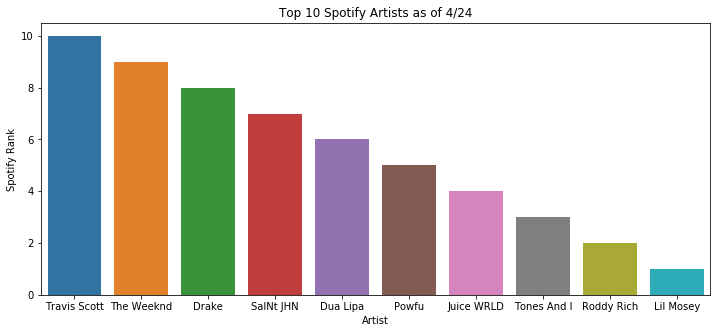

```python
plt.figure(figsize=(12, 5)) # set size of barplot
ax = sns.barplot(x='Artist', y='Rank', data=spotify_top_10) # barplot w/ artist and rank
plt.title('Top 10 Spotify Artists as of 4/24')
plt.xlabel('Artist')
plt.ylabel('Spotify Rank')
```

## Top 10 Apple Music Artists

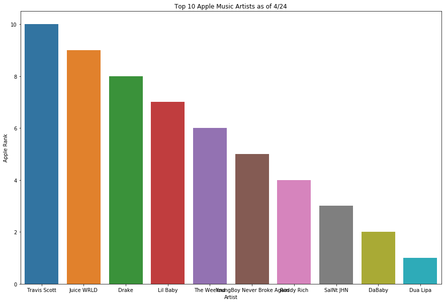

```python
plt.figure(figsize=(15, 10)) # set size of barplot
ax = sns.barplot(x='Artist', y='Rank', data=apple_top_10) # barplot w/ artist and rank
plt.title('Top 10 Apple Music Artists as of 4/24')
plt.xlabel('Artist')
plt.ylabel('Apple Rank')
```

We will use position_swap in conjunction with apply to make two new series - Our_Rank and Apple_Rank - both of which are the inverse of their respective positions

Now, we'll create a new column called "rank" which is essentially just the inverse of the artist's top 10 rating. This will allow us to make a barplot where the most popular artists have the biggest bars.

To do this, let's make a function called position_swap which will swap the positions of the values 1-10

```python
def position_swap(x):
    """function to swap values 1-10"""
    while True:
        if x==1:
            x=10
            break
        elif x==2:
            x=9
            break
        elif x==3:
            x=8
            break
        elif x==4:
            x=7
            break
        elif x==5:
            x=6
            break
        elif x==6:
            x=5
            break
        elif x==7:
            x=4
            break
        elif x==8:
            x=3
            break
        elif x==9:
            x=2
            break
        elif x==10:
            x=1
            break
    return x
```

```python
us_vs_apple['Our_Rank'] = us_vs_apple['Our_Position'].apply(position_swap) # our rank
us_vs_apple['Rank'] = us_vs_apple['Position'].apply(position_swap) # apple's rank
```

## Our Top 10 vs Apple Music's Top 10

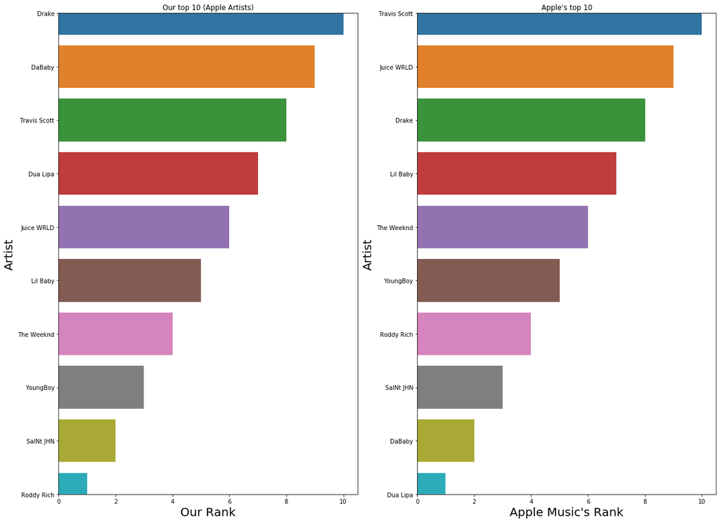

```python
f,ax=plt.subplots(1,2,figsize=(20,15))
sns.barplot('Our_Rank','Artist',data=us_vs_apple.sort_values('Our_Position'),orient='h',ax=ax[0])
ax[0].set_title('Our top 10 (Apple Artists)')
ax[0].set_yticks(range(0,10))
ax[0].set_ylabel("Artist",fontsize = 20)
ax[0].set_xlabel("Our Rank", fontsize = 20)
plt.gca().invert_xaxis()
#ax[0].barh('Our_Rank', 10)


### Complete code here to explore Sex and Age vs Survived
sns.barplot('Rank','Artist',data=us_vs_apple.sort_values('Position'),orient='h',ax=ax[1])
ax[1].set_title("Apple's top 10")
ax[1].set_yticks(range(0,10))
ax[1].set_ylabel("Artist", fontsize =20)
ax[1].set_xlabel("Apple Music's Rank",fontsize = 20)
plt.gca().invert_xaxis()
plt.show()
```

## Our Top 10 vs Spotify's Top 10

Let's do the same for Spotify

```python
us_vs_spotify['Our_Rank'] = us_vs_spotify['Our_Position'].apply(position_swap)
us_vs_spotify['Rank'] = us_vs_spotify['Position'].apply(position_swap)
```

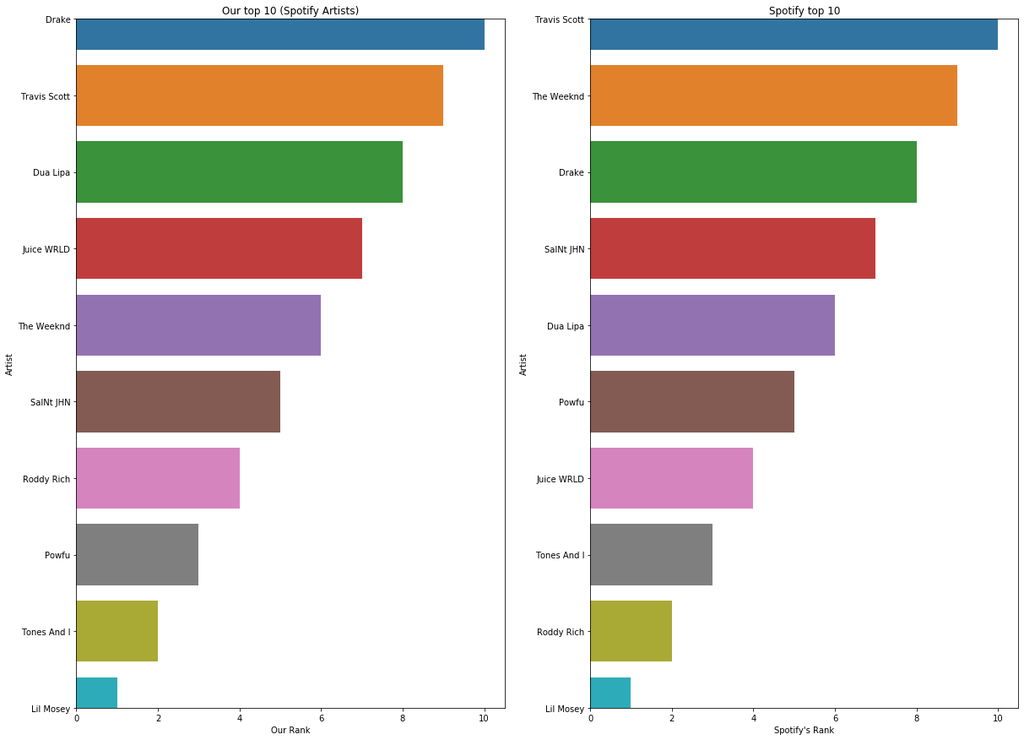

```python
f,ax=plt.subplots(1,2,figsize=(20,15))
sns.barplot('Our_Rank','Artist',data=us_vs_spotify.sort_values('Our_Position'),orient='h',ax=ax[0])
ax[0].set_title('Our top 10 (Spotify Artists)')
ax[0].set_yticks(range(0,10))
ax[0].set_ylabel("Artist")
ax[0].set_xlabel("Our Rank")
#plt.gca().invert_xaxis()
#ax[0].barh('Our_Rank', 10)


### Complete code here to explore Sex and Age vs Survived
sns.barplot('Rank','Artist',data=us_vs_spotify.sort_values('Position'),orient='h',ax=ax[1])
ax[1].set_title('Spotify top 10')
ax[1].set_yticks(range(0,10))
ax[1].set_ylabel("Artist")
ax[1].set_xlabel("Spotify's Rank")
#plt.gca().invert_xaxis()
plt.show()
```

## Final Line Plot

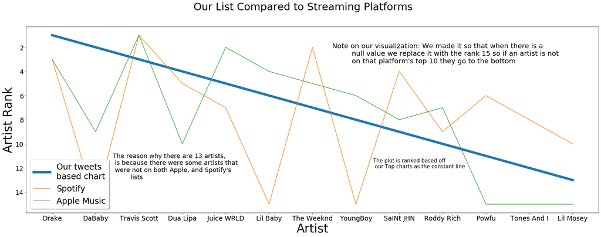

```python
final_ranking = final_ranking.sort_values('Our_Position')
final_ranking.replace(to_replace = "YoungBoy Never Broke Again", value = "Young Boy")
#Spotify12 = final_ranking["Spotify_Position"]
rank = np.arange(0,11)
Singers = final_ranking["Artist"]
Singers.replace(to_replace = "YoungBoy Never Broke Again", value = "Young Boy", inplace = True)
Our_rank = final_ranking["Our_Position"]
Spotify = final_ranking["Spotify_Position"]
Apple = final_ranking["Apple_Position"]
Apple = Apple.fillna(15)
Spotify = Spotify.fillna(15)
plt.figure(figsize=[30,10])
plt.xticks(fontsize = 19)
plt.yticks(fontsize = 19)
plt.plot(Singers, Our_rank, label = "Our tweets\nbased chart", linewidth = 7)
plt.plot(Singers, Spotify, label = "Spotify")
plt.plot(Singers, Apple, label = "Apple Music")
plt.legend(loc = "lower left", shadow = True, prop = {"size": 24})
plt.xlabel("Artist", fontsize = 35)
plt.ylabel("Artist Rank", fontsize = 35)
plt.suptitle("Our List Compared to Streaming Platforms", fontsize = 30)
plt.gca().invert_yaxis()
plt.text(6.45,3.3,"""Note on our visualization: We made it so that when there is a
         null value we replace it with the rank 15 so if an artist is not
         on that platform's top 10 they go to the bottom""", fontsize = 20)
plt.text(1.4,12.9, """The reason why there are 13 artists,\n is because there were some artists that\n were not on both Apple, and Spotify's
         lists""", fontsize = 18)
plt.text(7.4,12,"The plot is ranked based off\n our Top charts as the constant line",fontsize = 15)
```

## Wordcloud Based Off Of Tweet Location

```python
# install wordcloud library
!pip install wordcloud
```

```python
df["User_Location"].dropna(inplace = True)
from wordcloud import WordCloud, STOPWORDS

word_counts = {} # Initialize a Dictionary
for text in  df.User_Location:  #or the cleaned up text
    text = str(text).lower() # Convert to string
    for word in text.split(): # text.split()
        word_counts[word] = word_counts.get(word, 0) + 1


stopwords = set(STOPWORDS)
delete_present_stopwords=[key for key in word_counts if key in stopwords]
for key in delete_present_stopwords:
    del word_counts[key]
```

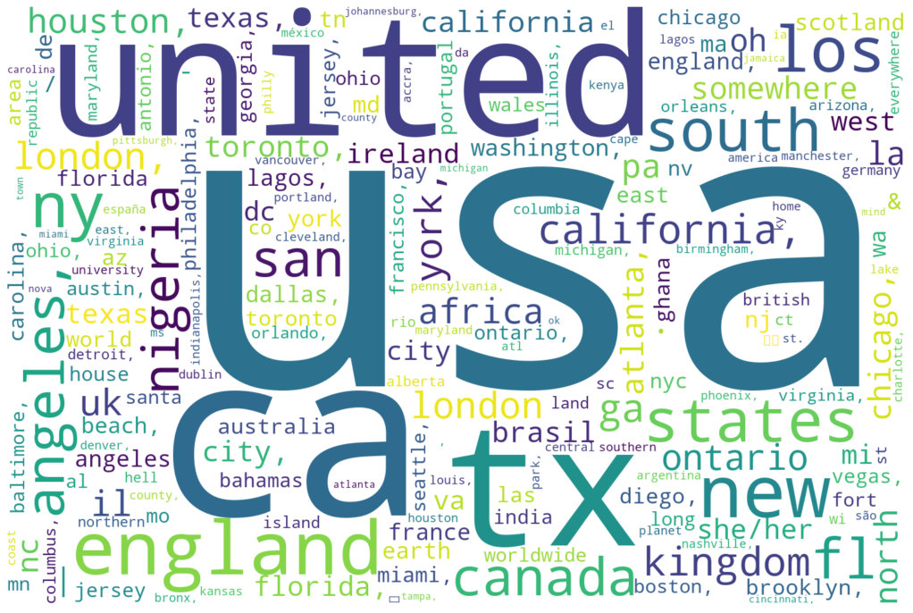

```python
import matplotlib
import matplotlib.pyplot as plt
import seaborn as sns

%matplotlib inline
wordcloud = WordCloud(stopwords=stopwords, width = 1500, height = 1000,
                background_color ='white',
                min_font_size = 10).generate_from_frequencies(word_counts)

plt.figure(figsize = (14, 14), facecolor = None)
plt.imshow(wordcloud, interpolation='bilinear')
plt.axis("off")
plt.tight_layout(pad = 0)
plt.show()
```

# Discussion

Throughout the process of this project, there were several aspects we had to think about before moving forward with our analysis. One major point of consideration for the group was to determine the key words to scrape for. At first, we scraped for an artist name, such as “Drake” followed by the streaming platform, “Apple Music”. When we analyzed these results, we saw that we didn’t have nearly enough data for an appropriate analysis. We then decided to change our keywords on our scapers to get the top 10 artists from Spotify and Apple Music’s top 10 charts, respectively. We also ran into an issue with the artist Lil Mosey - he did not have any hashtags during the time of our scraping. When we made our final equation to place our artists, we took the average rating of each artist’s total tweets and average rating of each artist’s hashtags. For Lil Mosey we simply used the average rating of his total tweets in our equation.

# Conclusion

Given our results, we conclude that Spotify's chart is more highly affected by the number of relatively high-quality tweets there are about an artist. Our ranking had an MSE of 8.77 compared to Spotify, while the MSE for Apple Music was 9.54. One major driving factor we thought would cause a disparity is the fact that our ranking method placed the three artists that were unique to Spotify’s charts as ranks 11, 12, and 13 out of a total of 13 artists. In addition, we can also see from the word cloud that most of our tweets come from users located in the United States, and more specifically from the states of California and Texas.

# Extra Analysis Attempt

Here we tried to scrape for the keywords such as 'track' 'new track' etc. to then make a list based off tweets where people mention an artist (so instead of scraping for the actual artist name, we "reversed engineered" the scraper to get keywords that might mention an artist name. Gave our best attempt, but did not get too much data for the given time frame.

## Keywords that were scraped

To create this list, we scraped for the following keywords for about 5 hours

- "Music, New Music, great music, just listened to, new release, new song, great track, track"

```python
#stream.statuses.filter(track="Music, New Music, great music, just listened to, new release, new song, great track, track")
```

## Our organic list based on tweets

```python
import pandas as pd
import re

new_df = pd.read_csv("twitter_output_OurList.csv")
new_df.columns= ['Hashtags','ID','Tweet_Text','Name','Username','User_Location','User_Description','Followers','Friends','Lists','Account_Creation_Date','Favorites','User_Total_Tweets']

col  = new_df.Tweet_Text
pages = col.to_string()
r = r"([A-Z][a-z]+ [A-Z][a-z]+)"
regex = re.compile(r)
match = regex.findall(pages)
match
x = pd.Series(match)
x.value_counts()
top10 = x.head(20)

#here we took what would match as a first name and last name, and got the counts of each value to make our new list
#but not sure how useful and accurate this would be, becuase the first artist name that looks familiar was at index 15
top_10  =pd.DataFrame(top10)
top_10.columns = ["Our Name"]
top_10
```

|  | Our Name |
| --- | --- |
| 0 | Stone Hello |
| 1 | Music Re |
| 2 | Solar Won |
| 3 | Virtual Community |
| 4 | Doug Fords |
| 5 | Korean Music |
| 6 | Big Machine |
| 7 | The South |
| 8 | Atlantic Conferen |
| 9 | Rapper Hae |
| 10 | Agent Francis |
| 11 | York Morgan |
| 12 | Only Girl |
| 13 | In The |
| 14 | Adriana Lima |
| 15 | Daft Punk |
| 16 | Kazunari Ninomiya |
| 17 | Taeyeon Shares |
| 18 | The Container |
| 19 | Ship Greetje |

```python
x.iloc[15] #looks much different than the Apple and Spotify top 10.
```

```
'Daft Punk'
```

```python
new_df = pd.read_csv("AllArtists.csv")#This dataframe that has a list of 3,00 artist names
artists = new_df["name"]
Artist_List = pd.DataFrame(artists)
Artist_List
```

|  | name |
| --- | --- |
| 0 | Adele |
| 1 | Joey + Rory |
| 2 | Draaco Aventura |
| 3 | Justin Bieber |
| 4 | Peer van Mladen |
| ... | ... |
| 2994 | Crosby, Stills, Nash & Young |
| 2995 | CRU |
| 2996 | Crystal Waters |
| 2997 | Crazy Town |
| 2998 | Cynthia Fetty |

2999 rows × 1 columns

# Geo-Map

```python
from mpl_toolkits.basemap import Basemap
```

```python
from geopy.geocoders import Nominatim
```

[output not shown]

```python
location = df["User_Location"].value_counts()
new_loc = location.to_string()
location #Taking the frequency of each location
locc = pd.DataFrame(location)
locc
```

|  | User_Location |
| --- | --- |
| United States | 1195 |
| Los Angeles, CA | 950 |
| California, USA | 813 |
| London, England | 572 |
| Houston, TX | 520 |
| ... | ... |
| BANGWINPINKONTREJO | 1 |
| My Location Unknow | 1 |
| Ahmadabad City, India | 1 |
| Des Moines, USA | 1 |
| East Helena, MT | 1 |

26444 rows × 1 columns

Here we are taking the top values from the Location and then taking the top 300 locations. We are taking the top 300, becuase if we attempt to pass in all 100,000 tweets, our kernel will time out. So due to that the most important 300 are used.

```python
e = df.User_Location.dropna()
ee = pd.DataFrame(e)
zg = ee.User_Location.value_counts().head(300)
ZG = zg.index
ZLG= pd.DataFrame(ZG)
ZLG.columns = ["Location"]
ZLG
```

|  | Location |
| --- | --- |
| 0 | United States |
| 1 | Los Angeles, CA |
| 2 | California, USA |
| 3 | London, England |
| 4 | Houston, TX |
| ... | ... |
| 295 | Ann Arbor, MI |
| 296 | Kenya |
| 297 | The Netherlands |
| 298 | Baltimore |
| 299 | The Bahamas |

300 rows × 1 columns

```python
e = df.User_Location.dropna()
ee = pd.DataFrame(e)
zg = ee.User_Location.value_counts().head(300)
count = pd.DataFrame(zg)
count
```

|  | User_Location |
| --- | --- |
| United States | 1195 |
| Los Angeles, CA | 950 |
| California, USA | 813 |
| London, England | 572 |
| Houston, TX | 520 |
| ... | ... |
| Ann Arbor, MI | 20 |
| Kenya | 20 |
| The Netherlands | 20 |
| Baltimore | 20 |
| The Bahamas | 20 |

300 rows × 1 columns

As far as we were able to get with the geo-plot. Were researching ways to plot, found geopy but ran out of time.

```python
pip install geopy
```

```python
import geopy
from geopy.geocoders import Nominatim
```

```python
nom = Nominatim()
```

```python
ZLG["Coordinates"] = ZLG["Location"].apply(nom.geocode)
```

```python
ZLG.dropna()
```

|  | Location | Coordinates |
| --- | --- | --- |
| 0 | United States | (United States, (39.7837304, -100.4458825)) |
| 1 | Los Angeles, CA | (Los Angeles, Los Angeles County, California, ... |
| 2 | California, USA | (California, United States of America, (36.701... |
| 3 | London, England | (London, Greater London, England, SW1A 2DX, Un... |
| 4 | Houston, TX | (Houston, Harris County, Texas, United States ... |
| ... | ... | ... |
| 295 | Ann Arbor, MI | (Ann Arbor, Washtenaw County, Michigan, United... |
| 296 | Kenya | (Kenya, (1.4419683, 38.4313975)) |
| 297 | The Netherlands | (Nederland, (52.5001698, 5.7480821)) |
| 298 | Baltimore | (Baltimore, Maryland, 21203, United States of ... |
| 299 | The Bahamas | (The Bahamas, (24.7736546, -78.0000547)) |

297 rows × 2 columns

```python
ZLG["Latitude"] = ZLG["Coordinates"].apply(lambda x: x.latitude if x != None else None)
ZLG["Longitude"] = ZLG["Coordinates"].apply(lambda x: x.longitude if x != None else None)
ZLG.dropna()
```

|  | Location | Coordinates | Latitude | Longitude |
| --- | --- | --- | --- | --- |
| 0 | United States | (United States, (39.7837304, -100.4458825)) | 39.783730 | -100.445882 |
| 1 | Los Angeles, CA | (Los Angeles, Los Angeles County, California, ... | 34.053691 | -118.242767 |
| 2 | California, USA | (California, United States of America, (36.701... | 36.701463 | -118.755997 |
| 3 | London, England | (London, Greater London, England, SW1A 2DX, Un... | 51.507322 | -0.127647 |
| 4 | Houston, TX | (Houston, Harris County, Texas, United States ... | 29.758938 | -95.367697 |
| ... | ... | ... | ... | ... |
| 295 | Ann Arbor, MI | (Ann Arbor, Washtenaw County, Michigan, United... | 42.268157 | -83.731229 |
| 296 | Kenya | (Kenya, (1.4419683, 38.4313975)) | 1.441968 | 38.431398 |
| 297 | The Netherlands | (Nederland, (52.5001698, 5.7480821)) | 52.500170 | 5.748082 |
| 298 | Baltimore | (Baltimore, Maryland, 21203, United States of ... | 39.290882 | -76.610759 |
| 299 | The Bahamas | (The Bahamas, (24.7736546, -78.0000547)) | 24.773655 | -78.000055 |

297 rows × 4 columns

```python
Lat = ZLG["Latitude"]
Long = ZLG["Longitude"]
```

```python
import numpy as np # linear algebra
import pandas as pd # data processing, CSV file I/O (e.g. pd.read_csv)
import seaborn as sns #Statistical Data Visualization
import matplotlib.pyplot as plt
%matplotlib inline
```

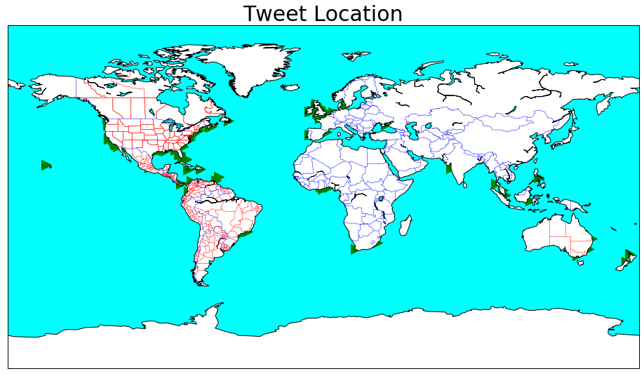

```python
from mpl_toolkits.basemap import Basemap
import matplotlib.pyplot as plt
fig = plt.figure(figsize=(20,9))
m = Basemap(projection='gall',
            resolution = 'c')
m.drawcoastlines()
m.drawcountries(color= 'blue')
m.drawstates(color= 'red')
m.drawmapboundary(fill_color='aqua')
m.fillcontinents(color='white',lake_color='aqua')
plt.title("Tweet Location",fontsize = 30)
Lat = list(ZLG["Latitude"])
Long = list(ZLG["Longitude"])
m.scatter(Long,Lat,latlon=True,color="green",marker = ">",s = 200)
plt.show()
```